# Journal Club Outline

## Outline:

1. Review some basic taste biology and genetics
2. Review and critique Hwang et al. (2018)

## PROP as a case study

## Discovering PROP

- Variability in bitter taste perception started in 1932 <sup>1</sup>
- Arthur Fox reported inter-subject variability in PTC perception
  - discrete categories of “taster” (sensitive) and “non-taster” (insensitive)
- PTC is toxic (not great for human science), so PROP has widely replaced PTC
  - PROP acts in a similar manner to PTC
- Both PROP and PTC are agonists of *TAS2R38*

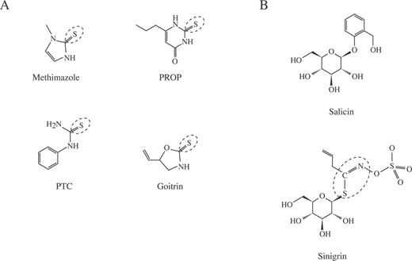

## Biology Review

- “Taster status” of PROP is the result of your **phenotype** <sup>2</sup>
  - the expression of a certain trait
- Phenotype is the result of your **genotype**
  - the genetic make up or specific combination of alleles
  - alleles are one of the versions of gene

## Back to PROP

- rs10246939 (on chromosome 7)
  - explains ~50% of variance seen in detection thresholds <sup>1</sup>
  - this SNP here has a MAF of ~46% <sup>1</sup>
- this is at a **SNP**, or single nucleotide polymorphism
  - a SNP is a single change in a base pair, resulting in genetic variation
  - usually high frequency <sup>3</sup>
  - *mutations* are generally reserved for low frequency genetic variation <sup>3</sup>

## Other factors influencing PROP sensitivity

From Robino et al. (2022):

- fungiform pappilae count/density
- age
- gender
- salivary flow rate and protein composition

## Hwang et al. (2018)

## Introduction

- Bitterness is a basic taste, but isn’t perceived the same way for everyone
- 36-73% of bitterness perception is due to genetics <sup>6</sup>
- Other factors can influence taste perception <sup>4</sup>
- PROP bitterness has been implicated in fat perception <sup>7</sup>
- PTC related to diseases <sup>8</sup>, immune system, and surgical outcome of severe rhinosinusitis <sup>6</sup>
- Want to understand “underlying genetic variation that leads to individual differences in bitter perception”
  - this could have implications in “personalized medicine” <sup>3,6</sup>

## Previous GWAS study - Reed et al. (2010)

- Previous GWAS (Reed et al. (2010)) replicated association between *TAS2R38* and PROP perception
- Identified a SNP within *TAS2R19*: accounting for 5.8% of variance in quinine perception
- Did not find loci for caffeine, SOA, or proposed second locus for PTC/PROP

## Methods

## What is a GWAS?

- GWAS studies aim to identify genetic risk factors for common diseases by utilizing DNA sequence variations <sup>3</sup>
  - the goal/outcome is to identify biological underpinnings of disease susceptibility, predict at-risk groups, and develop new prevention/treatments
- tests each SNP for an independent association to a phenotype
- By genotyping SNPs from each haplotype in the genome in disease cases and healthy controls, it is possible to identify SNPs where the allele frequency is significantly different between the cases and controls, and which are associated with the disease.
- is not necessarily hypothesis driven
  - replications might be

## Modeling

- linear mixed model
  - covariates (fixed effects): age, sex, ear infection history, first 5 PC from genotype
  - used additive model - for each copy of allele *A*, there is a uniform, linear increase in risk <sup>3</sup>
- bivariate analysis can complement univariate analysis
  - can enhance the strength of a SNP association, but not effect size <sup>6</sup>
- variance explained by SNP was calculated as \(2* MAF* (1-MAF)* \beta^2\)

## Taste Perception

- presented 5 bitter samples with reps
  - 0.181 mM quinine HCl
  - 0.050 M caffeine
  - 0.6 mM PROP
  - 0.2 mM SOA
  - 0.00499 mM denatonium benzoate
  - same order presentation for all participants
- previous GWAS <sup>5</sup> used 1 mL solution
- swish and spit after 5 s, rate on LMS <sup>10</sup>
- bitter scores were square root transformed then converted to z-scores

#### Functional annotation of identified SNPs

- functional annotation can be used to identify any potential roles of the identified SNPs
  - could be used to identify/develop mechanistic hypotheses in understanding variance in taste perception based on the identified/associates SNPs
- *do I need to expand this section?*

### Results

- confirmed associations with PROP (rs10246939) and quinine (rs10772420) from Reed et al. (2010)
- identified and provide independent rep for caffeine (rs2597979)

#### PROP

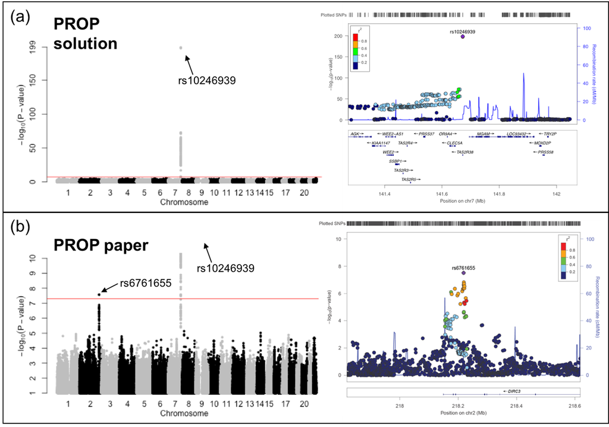

- strong association with rs10246939 on chromosome 7 (the “classic” SNP)
  - seen in Reed et al. (2010) as well
- no signals on chromosomes 5 or 16, where additional loci are proposed
- PROP paper showed association on chromosome 2, rs6761655
  - appeared in Reed et al. (2010) but was weak and therefore not reported
  - not reported in other GWAS studies using PROP

#### Quinine

[figure not shown]

#### Caffeine

- peak at rs2597979 (chromosome 12; p = \(4.2*10^{-8}\))
  - provided an independent replication of this SNP with caffeine (Ledda et al. (2014))
  - caffeine-rs2597979 association remained after conditional analysis with rs10772420 (top quinine SNP, \(r^2\) = 0.24)
  - explained 1.91% trait variance (6.15% genetic variance; **Table S9**)
- rs2597979 was not associated with SOA or DB (explained 0.16% and 0.05% genetic variance, respectively)

#### Functional Analysis

Brief summary (from Table S11) (mTQL = methylation quantitative trait loci; eQTL = expression quantitative trait loci)

- 1. PROP, quinine, caffeine, and SOA-associated SNPs include missense variants.
- 1. PROP, quinine, and DB-associated SNPs are located within conserved region.
- 1. Except for caffeine-associated SNPs, all SNPs are in high DNAse hypersensitivity sites.
- 1. PROP, SOA, and DB-associated SNPs are inside promoter and/or enhancer regions.
- 1. All SNPs may cause regulatory motif change of a protein.
- 1. All SNPs are eQTLs.
- 1. Quinine, caffeine, and SOA-associated SNPs are mQTLs.
- 1. None of these analyses was performed using taste tissues.

(Is this important to focus on and understand?)

## Appendix

## References

Delwiche, Jeannine F, Zivjena Buletic, and Paul A S Breslin. 2001. “Covariation in Individuals’ Sensitivities to Bitter Compounds: Evidence Supporting Multiple Receptor/Transduction Mechanisms.” *Percept. Psychophys.* 63 (5): 761–76.

Genick, Ulrich K, Zoltán Kutalik, Mirko Ledda, Maria C Souza Destito, Milena M Souza, Cintia A Cirillo, Nicolas Godinot, et al. 2011. “Sensitivity of Genome-Wide-Association Signals to Phenotyping Strategy: The PROP-TAS2R38 Taste Association as a Benchmark.” *PLoS One* 6 (11): e27745.

Hansen, J. L., Danielle Reed, Margaret Wright, Nicholas Martin, and Paul Breslin. 2006. “Heritability and Genetic Covariation of Sensitivity to Prop, SOA, Quinine Hcl, and Caffeine.” *Chemical Senses* 31 (5): 403–13. https://doi.org/10.1093/chemse/bjj044.

Hwang, Liang-Dar, Puya Gharahkhani, Paul A. S. Breslin, Scott D. Gordon, Gu Zhu, Nicholas G. Martin, Danielle R. Reed, and Margaret J. Wright. 2018. “Bivariate Genome-Wide Association Analysis Strengthens the Role of Bitter Receptor Clusters on Chromosomes 7 and 12 in Human Bitter Taste.” *BMC Genomics* 19 (1): 678. https://doi.org/10.1186/s12864-018-5058-2.

Ledda, Mirko, Zoltán Kutalik, Maria C Souza Destito, Milena M Souza, Cintia A Cirillo, Amabilene Zamboni, Nathalie Martin, et al. 2014. “ GWAS of Human Bitter Taste Perception Identifies New Loci and Reveals Additional Complexity of Bitter Taste Genetics.” *Hum. Mol. Genet.* 23 (1): 259–67.

Reed, Danielle R, Gu Zhu, Paul A S Breslin, Fujiko F Duke, Anjali K Henders, Megan J Campbell, Grant W Montgomery, Sarah E Medland, Nicholas G Martin, and Margaret J Wright. 2010. “The Perception of Quinine Taste Intensity Is Associated with Common Genetic Variants in a Bitter Receptor Cluster on Chromosome 12.” *Hum. Mol. Genet.* 19 (21): 4278–85.

Robino, Antonietta, Maria Pina Concas, Sara Spinelli, Lapo Pierguidi, Beverly J Tepper, Paolo Gasparini, John Prescott, et al. 2022. “Combined Influence of TAS2R38 Genotype and PROP Phenotype on the Intensity of Basic Tastes, Astringency and Pungency in the Italian Taste Project.” *Food Qual. Prefer.* 95 (104361): 104361.